# S&P 500 Governance and Financial Panel Dataset

Author

Barry

## Overview

This project constructs a structured firm-year panel of S&P 500 companies from 2003 to 2023, integrating board diversity, financial performance, and ESG disclosures from WRDS and third-party sources. It is designed to support empirical research in corporate governance, ESG, and board diversity.

### Data Sources:

- **BoardEx (North America)**: Director-level demographics and board service data
- **Compustat (Fundamentals Annual)**: Financial accounting and market-based metrics
- **Refinitiv & Bloomberg**: ESG scores and historical S&P 500 membership
- **WRDS Cloud**: PostgreSQL backends and Python JupyterHub for computation

## Key Files

### ✅ `master_panel_deduplicated.csv`

**Final merged and deduplicated panel** with one row per firm-year. This is the primary dataset for analysis, missingness diagnostics, and regression modelling.

#### Core Variables

| Variable | Description |
| --- | --- |
| `gvkey`, `ticker`, `conm` | Compustat identifiers and company metadata |
| `fiscal_year` | Fiscal year (used for merging and aggregation) |
| `numberdirectors` | Board size (BoardEx, from annual report) |
| `pct_female_directors` | Fraction of female directors (BoardEx-derived) |
| `estimated_num_female_directors` | Approximated count of women on board |
| `avg_age`, `stdev_age` | Age statistics for board directors |
| `tobins_q`, `roa`, `liquidity_ratio`, `leverage_ratio` | Financial ratios (Compustat) |
| `ref_ESGScore`, `bbg_SOCIAL_SCORE` | ESG scores from Refinitiv and Bloomberg |

**Intermediate file**: contains governance and financial variables prior to merging with Bloomberg and Refinitiv ESG data.

### 📄 `director_level_data_filtered.csv`

Director-year-level data filtered from BoardEx, used to compute firm-level diversity stats.

### 📄 `boardex_director_diversity_by_company_year.csv`

Intermediate file: company-year aggregates of gender and age diversity from BoardEx.

## Construction Workflow

### `wrds_sp500_data.qmd`

A **Quarto notebook** orchestrating the initial pipeline: 1. Extracts and cleans BoardEx director data 2. Joins Compustat financials by `gvkey` and fiscal year 3. Filters companies by point-in-time S&P 500 membership 4. Outputs `sp500_panel_full_with_diversity.csv` as an intermediate dataset

### `merge_with_refinitiv_bloomberg.py`

A **Python script** for final panel construction: - Reads `sp500_panel_full_with_diversity.csv` - Merges Bloomberg and Refinitiv ESG data - Deduplicates based on `gvkey` and `fiscal_year` - Outputs **`master_panel_deduplicated.csv`** as the final panel

## Time Coverage

- **Years**: 2003–2023 (only for wrds data)
- **Universe**: S&P 500 constituents at each year-end (via Refinitiv/Bloomberg)

## Sample Size

- Over 12,000 unique firm-year observations (only for wrds data)
- One row per `(gvkey, fiscal_year)`
- Restricted to S&P 500 members during each fiscal year

## Missing Data and Regression Inputs

A key concern in panel-based empirical research is variable completeness across firm-years. The final dataset, `master_panel_deduplicated.csv`, integrates financial, governance, and ESG indicators, with varying coverage by source.

To aid transparency, we conducted a targeted missingness analysis for **regression-relevant variables**, including:

- Tobin’s Q (multiple sources)
- Liquidity and leverage ratios
- Board gender diversity
- ESG summary scores

### 📊 Missingness Matrix: Regression Inputs

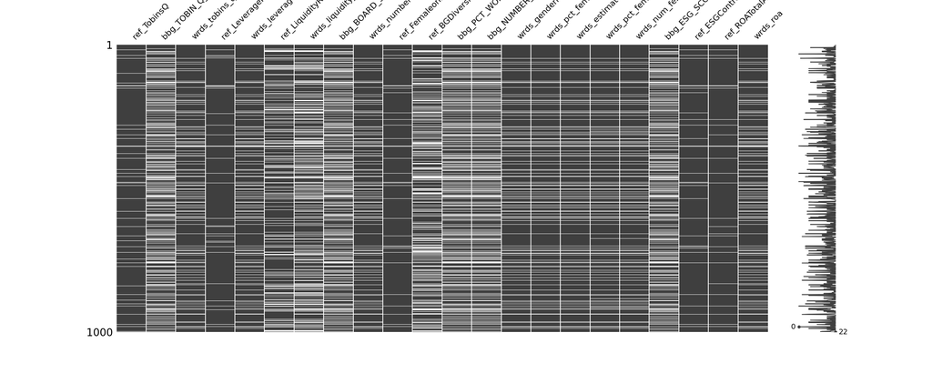

This visual highlights:

- Good coverage from **Refinitiv** and **WRDS (Compustat)** for core financials
- Sparse coverage from **Bloomberg**, especially on board metrics and ESG disclosures
- Some redundancy across data providers (e.g. Tobin’s Q from WRDS, Refinitiv, Bloomberg)

### Summary: Variable Coverage for Regression

| Type | Fields (examples) | Coverage |
| --- | --- | --- |
| **High** | `ref_TobinsQ`, `ref_ROATotalAssetsPercent`, `ref_LeverageRatio`, `wrds_pct_female_directors`, `numberdirectors` | ✅ Broad coverage |
| **Moderate** | `wrds_tobins_q`, `wrds_roa`, `wrds_leverage_ratio`, `avg_age`, `stdev_age` | ⚠ Some gaps |
| **Low** | Bloomberg ESG metrics (e.g. `bbg_PCT_WOMEN`, `bbg_ESG_SCORE`) | ❌ Sparse |

## Dependencies

Built using WRDS Cloud JupyterHub with:

- Python: `wrds`, `pandas`, `datetime`, `pyarrow`
- Notebook: `Quarto` (`wrds_sp500_data.qmd`)
- Merge script: `merge_with_refinitiv_bloomberg.py`
- Visualisation: `missingno`, `matplotlib`